# Simulating study data: introduction

Keith S. Goldfeld

2019-02-07

Simulation using `simstudy` has two primary steps. First, the user **defines** the data elements of a data set. Second, the user **generates** the data, using the definitions in the first step. Additional functionality exists to simulate observed or randomized **treatment assignment/exposures**, to generate **survival** data, to create **longitudinal/panel** data, to create **multi-level/hierarchical** data, to create datasets with **correlated variables** based on a specified covariance structure, to **merge** datasets, to create data sets with **missing** data, and to create non-linear relationships with underlying **spline** curves.

This vignette provides a brief introduction to the basics of generating data. For information on more elaborate data generating mechanisms, please visit https://www.rdatagen.net/page/simstudy/.

## Defining the Data

The key to simulating data in `simstudy` is the creation of series of data definition tables that look like this:

| varname | formula | variance | dist | link |
| --- | --- | --- | --- | --- |
| nr | 7 | 0e+00 | nonrandom | identity |
| x1 | 10;20 | 0e+00 | uniform | identity |
| y1 | nr + x1 * 2 | 8e+00 | normal | identity |
| y2 | nr - 0.2 * x1 | 0e+00 | poisson | log |
| xnb | nr - 0.2 * x1 | 5e-02 | negBinomial | log |
| xCat | 0.3;0.2;0.5 | 0e+00 | categorical | identity |
| g1 | 5+xCat | 1e+00 | gamma | log |
| b1 | 1+0.3*xCat | 1e+00 | beta | logit |
| a1 | -3 + xCat | 0e+00 | binary | logit |
| a2 | -3 + xCat | 1e+02 | binomial | logit |

These *definition* tables can be generated two ways. One option is to to use any external editor that allows the creation of `csv` files, which can be read in with a call to `defRead`. An alternative is to make repeated calls to the function `defData`. Here, we illustrate the R code that builds this definition table internally:

```r
def <- defData(varname = "nr", dist = "nonrandom", formula = 7, id = "idnum")
def <- defData(def, varname = "x1", dist = "uniform", formula = "10;20")
def <- defData(def, varname = "y1", formula = "nr + x1 * 2", variance = 8)
def <- defData(def, varname = "y2", dist = "poisson", formula = "nr - 0.2 * x1",
    link = "log")
def <- defData(def, varname = "xnb", dist = "negBinomial", formula = "nr - 0.2 * x1",
    variance = 0.05, link = "log")
def <- defData(def, varname = "xCat", formula = "0.3;0.2;0.5", dist = "categorical")
def <- defData(def, varname = "g1", dist = "gamma", formula = "5+xCat", variance = 1,
    link = "log")
def <- defData(def, varname = "b1", dist = "beta", formula = "1+0.3*xCat", variance = 1,
    link = "logit")
def <- defData(def, varname = "a1", dist = "binary", formula = "-3 + xCat",
    link = "logit")
def <- defData(def, varname = "a2", dist = "binomial", formula = "-3 + xCat",
    variance = 100, link = "logit")
```

The first call to `defData` without specifying a definition name (in this example the definition name is *def*) creates a **new** data.table with a single row. An additional row is added to the table `def` each time the function `defData` is called. Each of these calls is the definition of a new field in the data set that will be generated. In this example, the first data field is named ‘nr’, defined as a constant with a value to be 7. In each call to `defData` the user defines a variable name, a distribution (the default is ‘normal’), a mean formula (if applicable), a variance parameter (if applicable), and a link function for the mean (defaults to ‘identity’).

The possible distributions include **normal**, **gamma**, **poisson**, **zero-truncated poisson**, **negative binomial**, **binary**, **binomial**, **beta**, **uniform**, **uniform integer**, **categorical**, and **deterministic/non-random**. For all of these distributions, key parameters defining the distribution are entered in the `formula`, `variance`, and `link` fields.

In the case of the **normal**, **gamma**, **beta**, and **negative binomial** distributions, the formula specifies the mean. The formula can be a scalar value (number) or a string that represents a function of previously defined variables in the data set definition (or, as we will see later, in a previously generated data set). In the example, the mean of `y1`, a normally distributed value, is declared as a linear function of `nr` and `x1`, and the mean of `g1` is a function of the category defined by `xCat`. The `variance` field is defined only for normal, gamma, beta, and negative binomial random variables, and can only be defined as a scalar value. In the case of gamma, beta, and negative binomial variables, the value entered in variance field is really a dispersion value $d$. The variance of a gamma distributed variable will be $d \times mean^2$, for a beta distributed variable will be $mean \times (1- mean)/(1 + d)$, and for a negative binomial distributed variable, the variance will be $mean + d*mean^2$.

In the case of the **poisson**, **zero-truncated poisson**, and **binary** distributions, the formula also specifies the mean. The variance is not a valid parameter in these cases, but the `link` field is. The default link is ‘identity’ but a ‘log’ link is available for the Poisson distributions and a “logit” link is available for the binary outcomes. In this example, `y2` is defined as Poisson random variable with a mean that is function of `nr` and `x1` on the log scale. For binary variables, which take a value of 0 or 1, the formula represents probability (with the ‘identity’ link) or log odds (with the ‘logit’ link) of the variable having a value of 1. In the example, `a1` has been defined as a binary random variable with a log odds that is a function of `xCat`.

In the case of the *binomial* distribution, the formula specifies the probability of success $p$, and the variance field is used to specify the number of trials $n$. The mean of this distribution is $n*p$, and the variance is $n*p*(1-p)$.

Variables defined with a **uniform**, **uniform integer**, **categorical**, or **deterministic/non-random** distribution are specified using the formula only. The `variance` and `link` fields are not used in these cases.

For a uniformly distributed variable, The formula is a string with the format “a;b”, where *a* and *b* are scalars or functions of previously defined variables. The uniform distribution has two parameters - the minimum and the maximum. In this case, *a* represents the minimum and *b* represents the maximum.

For a categorical variable with $k$ categories, the formula is a string of probabilities that sum to 1: “$p_1 ; p_2 ; ... ; p_k$”. $p_1$ is the probability of the random variable falling category 1, $p_2$ is the probability of category 2, etc. The probabilities can be specified as functions of other variables previously defined. In the example, `xCat` has three possibilities with probabilities 0.3, 0.2, and 0.5, respectively.

Non-random variables are defined by the formula. Since these variables are deterministic, variance is not relevant. They can be functions of previously defined variables or a scalar, as we see in the sample for variable defined as `nr`.

## Generating the Data

After the data set definitions have been created, a new data set with $n$ observations can be created with a call to function **`genData`**. In this example, 1,000 observations are generated using the data set definitions in **`def`**, and then stored in the object **`dt`**:

```r
dt <- genData(1000, def)
dt
```

```
##       idnum nr       x1       y1  y2 xnb xCat        g1        b1 a1 a2
##    1:     1  7 18.71470 48.13110  25  36    3  882.3611 0.9707256  1 48
##    2:     2  7 12.63977 34.82680  87  97    3 1986.9499 0.8497208  1 54
##    3:     3  7 13.21247 34.96022  80  71    2 1460.2205 0.7136439  0 26
##    4:     4  7 19.21613 38.93975  17  16    1   77.6381 0.9997095  0 14
##    5:     5  7 10.70988 24.16021 148 110    2  696.4741 0.9546023  0 32
##   ---
##  996:   996  7 12.69114 34.43474  88 117    1  480.9245 0.3714678  0 10
##  997:   997  7 11.48129 31.34903 108 125    1  235.4808 0.9427933  0 13
##  998:   998  7 16.88184 41.60436  45  50    3 2425.0456 0.9999994  1 51
##  999:   999  7 10.24263 25.36589 151 107    3 2537.5048 0.9978473  0 49
## 1000:  1000  7 12.72076 33.53079  78  70    1  605.9685 0.4719441  0 13
```

```r
addef <- defDataAdd(varname = "zExtra", dist = "normal", formula = "3 + y1",
    variance = 2)

dt <- addColumns(addef, dt)
dt
```

```
##       idnum nr       x1       y1  y2 xnb xCat        g1        b1 a1 a2
##    1:     1  7 18.71470 48.13110  25  36    3  882.3611 0.9707256  1 48
##    2:     2  7 12.63977 34.82680  87  97    3 1986.9499 0.8497208  1 54
##    3:     3  7 13.21247 34.96022  80  71    2 1460.2205 0.7136439  0 26
##    4:     4  7 19.21613 38.93975  17  16    1   77.6381 0.9997095  0 14
##    5:     5  7 10.70988 24.16021 148 110    2  696.4741 0.9546023  0 32
##   ---
##  996:   996  7 12.69114 34.43474  88 117    1  480.9245 0.3714678  0 10
##  997:   997  7 11.48129 31.34903 108 125    1  235.4808 0.9427933  0 13
##  998:   998  7 16.88184 41.60436  45  50    3 2425.0456 0.9999994  1 51
##  999:   999  7 10.24263 25.36589 151 107    3 2537.5048 0.9978473  0 49
## 1000:  1000  7 12.72076 33.53079  78  70    1  605.9685 0.4719441  0 13
##         zExtra
##    1: 53.34158
##    2: 35.55258
##    3: 39.74581
##    4: 38.61562
##    5: 27.66564
##   ---
##  996: 39.48614
##  997: 35.11438
##  998: 43.95011
##  999: 27.75513
## 1000: 38.88947
```

## Generating the Treatment/Exposure

Treatment assignment can be accomplished through the original data generation process, using `defData` and `genData`. However, the functions `trtAssign` and `trtObserve` provide more options to generate treatment assignment.

### Assigned treatment

Treatment assignment can simulate how treatment is made in a randomized study. Assignment to treatment groups can be (close to) balanced (as would occur in a block randomized trial); this balancing can be done without or without strata. Alternatively, the assignment can be left to chance without blocking; in this case, balance across treatment groups is not guaranteed, particularly with small sample sizes.

First, create the data definition:

```r
def <- defData(varname = "male", dist = "binary", formula = 0.5, id = "cid")
def <- defData(def, varname = "over65", dist = "binary", formula = "-1.7 + .8*male",
    link = "logit")
def <- defData(def, varname = "baseDBP", dist = "normal", formula = 70, variance = 40)

dtstudy <- genData(330, def)
```

*Balanced treatment assignment, stratified by gender and age category (not blood pressure)*

```r
study1 <- trtAssign(dtstudy, n = 3, balanced = TRUE, strata = c("male", "over65"),
    grpName = "rxGrp")

study1
```

```
##      cid rxGrp male over65  baseDBP
##   1:   1     3    1      0 69.71811
##   2:   2     1    0      0 68.21481
##   3:   3     3    1      0 63.64589
##   4:   4     2    0      0 67.40492
##   5:   5     3    0      0 72.96366
##  ---
## 326: 326     1    1      1 67.99205
## 327: 327     3    1      0 55.73555
## 328: 328     3    1      0 74.85385
## 329: 329     3    1      0 75.20651
## 330: 330     3    1      0 66.24796
```

*Balanced treatment assignment (without stratification)*

```r
study2 <- trtAssign(dtstudy, n = 3, balanced = TRUE, grpName = "rxGrp")
```

*Random (unbalanced) treatment assignment*

```r
study3 <- trtAssign(dtstudy, n = 3, balanced = FALSE, grpName = "rxGrp")
```

*Comparison of three treatment assignment mechanisms*

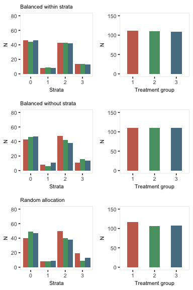

### Observed treatment

If exposure or treatment is observed (rather than randomly assigned), use `trtObserve` to generate groups. There may be any number of possible exposure or treatment groups, and the probability of exposure to a specific level can depend on covariates already in the data set. In this case, there are three exposure groups that vary by gender and age:

```r
formula1 <- c("-2 + 2*male - .5*over65", "-1 + 2*male + .5*over65")
dtExp <- trtObserve(dtstudy, formulas = formula1, logit.link = TRUE, grpName = "exposure")
```

Here are the exposure distributions by gender and age:

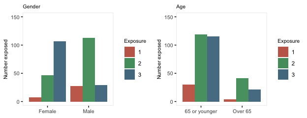

Here is a second case of three exposures where the exposure is independent of any covariates. Note that specifying the formula as `c(.35, .45)` is the same as specifying it is `c(.35, .45, .20)`. Also, when referring to probabilities, the identity link is used:

```r
formula2 <- c(0.35, 0.45)

dtExp2 <- trtObserve(dtstudy, formulas = formula2, logit.link = FALSE, grpName = "exposure")
```

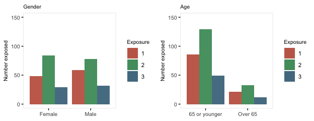